# rB3 demo for GLEON-20 pre-meeting workshop

## Apply filters using ‘ctrls’ values

### filterRoc() - Filter data by rate of change

Replace values exceedign specified rate of change with NA

?filterRoc

```r
rB3agg2 <- filterRoc(rB3agg2,
                     varNames = c('TmpWtr.d00050','TmpWtr.d00150'),
                     maxRoc = 0.5,
                     showPlot = T)
```

```
Apply these changes?

1: Yes
2: No
```

```
[1] "Changes have been applied"
```

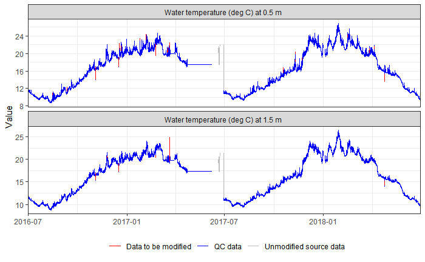

```r
1
```

If showPlot is TRUE, so you must enter your choice (1 = accept, 2 = decline) to continue

### filterReps() - filter by repeated values

Replace data where identical value has been repeated more than n = maxReps

?filterReps

```r
rB3agg2 <- filterReps(rB3agg2,
                      varNames = c('TmpWtr.d00050','TmpWtr.d00150'),
                      maxReps = 20,
                      showPlot = T)
```

```
Apply these changes?

1: Yes
2: No
```

```
[1] "Changes have been applied"
```

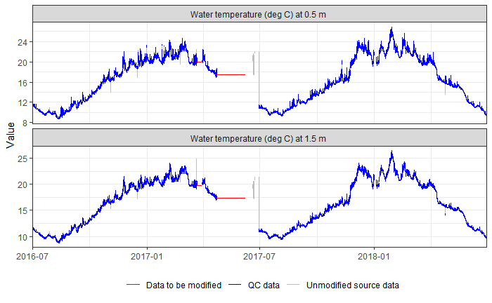

```r
1
```

### filterMinMax() - limit data value by range

Filter data below minVal or above maxVal (either specified, or from ‘ctrls’/headers)

?filterMinMax

```r
rB3agg2 <- filterMinMax(rB3agg2,
                        varNames = c('TmpWtr.d00050','TmpWtr.d00150'),
                       filterMin = 9,
                       filterMax = 25,
                       showPlot = T)
```

```
Apply these changes?

1: Yes
2: No
```

```
[1] "Changes have been applied"
```

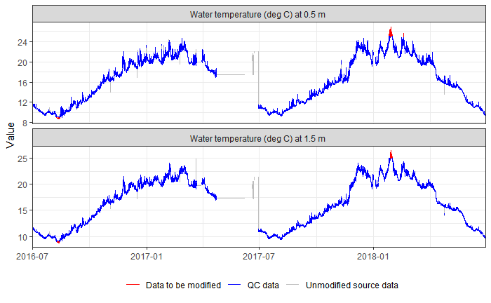

```r
1
```

### applyInterp() - linearly interpolate NA values

?applyInterp

```r
rB3agg2 <- applyInterp(rB3agg2,
                       varNames = c('TmpWtr.d00050','TmpWtr.d00150'),
                       showPlot = T)
```

```
Apply these changes?

1: Yes
2: No
```

```
[1] "Changes have been applied"
```

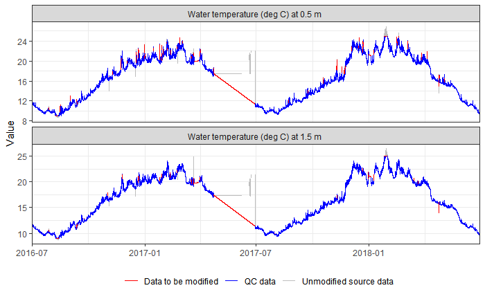

```r
1
```

## Visualise your rB3 process

### logsPlot() - visualise source, QC data and modifications log

?logsPlot

visualise changes to data

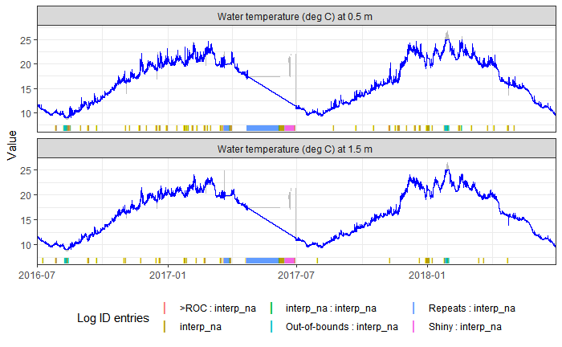

```r
logsPlot(rB3in = rB3agg2,
         varNames = c('TmpWtr.d00050','TmpWtr.d00150'),
         srcColour = 'grey')
```

?rB3gg

View the final before and after, without logs

```
[1] "Only quality controlled data are displayed for non-faceted plots"
```

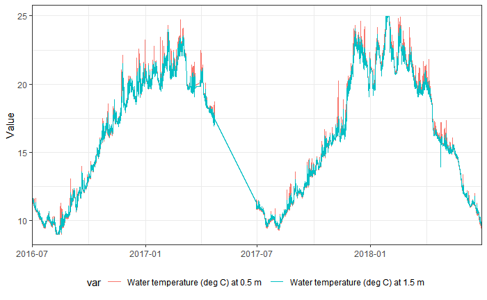

```r
rB3gg(rB3in = rB3agg2,
      varNames = c('TmpWtr.d00050','TmpWtr.d00150'),
      srcColour = 'orange',
      qcColour = 'blue') #, savePlot = 'figures/RAW_WQ_',  dpi = 400)
```

### rB3export() EXPORTING rB3 DATA

Export data from the rB3 object into csv files

?rB3export

```r
rB3export(rB3agg2,
          varNames = 'All',
          qc = T,
          src = T,
          metadata = T)
```

```r
rB3agg3 <- rB3agg2
```

## Advanced QA/QC function

### applyNth()

Apply a mathematical transformation, e.g. new = a + b(old) + c(old)^2 + c(old)^3 + …etc

?applyNth

```r
rB3agg2 <- applyNth(rB3in = rB3agg2,
                    startDate = '2016-07-01 00:00:00',
                    endDate = '2017-06-28 23:45:00',
                    varNames = 'DOpsat.d00050',
                    coeffs = c(12,1,0.02),
                    showPlot = T)
```

```
Apply these changes?

1: Yes
2: No
```

```
[1] "Changes were not applied"
```

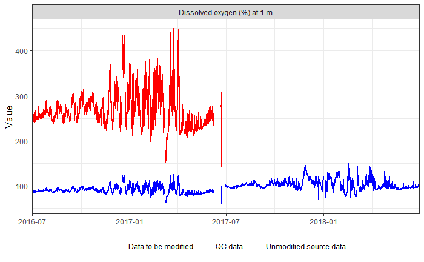

```r
2
```

### driftCorr()

Correct linear sensor drift (assumes consistent timestep)

?driftCorr

```r
rB3agg2 <- driftCorr(rB3agg2,
                     '2016-07-01 00:00:00',
                     '2017-06-28 23:45:00',
                     'DOpsat.d00050',
                     lowRef = 0,
                     lowStart =  0,
                     lowEnd =  0,
                     highRef = 100,
                     highStart = 85,
                     highEnd = 130,
                     showPlot = T)
```

```
Apply these changes?

1: Yes
2: No
```

```
[1] "Changes have been applied"
```

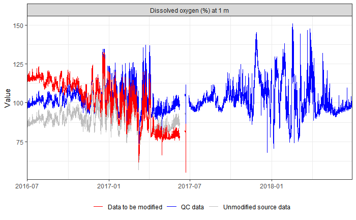

```r
1
```

## Some useful functions

### tmprAlign()

?tmprAlign

Post-calibrate temperature sensors based on periods of mixing, as found by temp differences and wind speed (optional)

**Pre tmprAlign()**

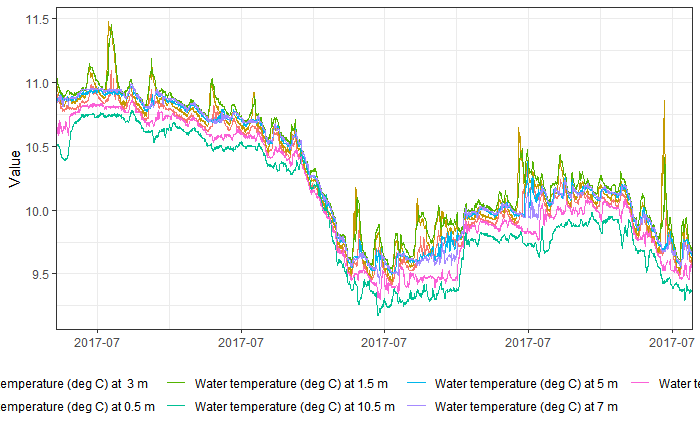

```r
rB3gg(rB3in = rB3agg2,
      varNames = 'TmpWtr',
      startDate = '2017-07-01',
      endDate = '2017-08-01',
      facet = FALSE,
      showPlot = T)
```

```r
rB3agg2 <- tmprAlign(rB3agg2,
                     varNames = 'TmpWtr',
                     dTPerctile = 0.2,
                     logID = "tpmAlign",
                     Reason = "Interp",
                     showPlot = T,
                     plotType = 'All')
```

```
Apply these changes?

1: Yes
2: No
```

```
[1] "Changes have been applied"
```

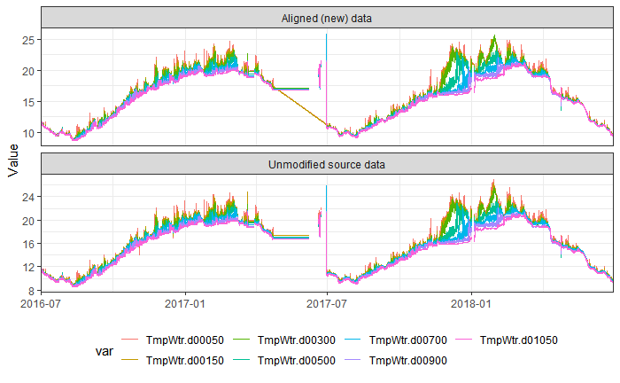

```r
1
```

**Post tmprAlign()**

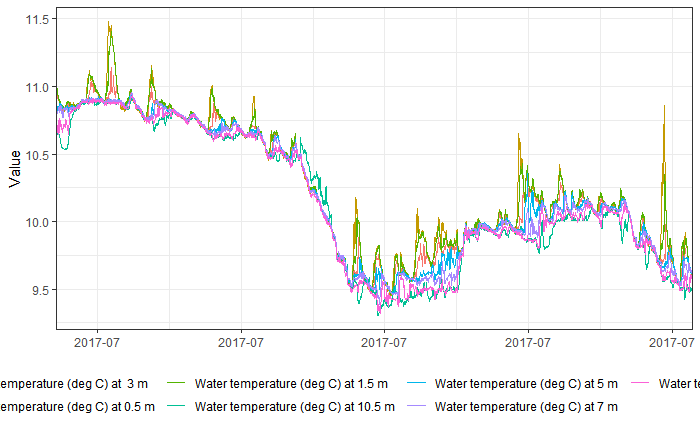

```r
rB3gg(rB3in = rB3agg2,
      varNames = 'TmpWtr',
      startDate = '2017-07-01',
      endDate = '2017-08-01',
      facet = FALSE,
      showPlot = T)
```

### FUNCrB3() - apply your own equation

?FUNCrB3 Apply a custom function using rB3

**Simple example:**

multiply a variable by 2

```r
# define a simple function ( result = input variable * 2)
test <- function(eqnVars) {eqnVars[1] * 2}
# apply this custom function
rB3agg2 <- FUNCrB3(rB3agg2,
                   varNames = 'DOpsat.d00050',
                   eqnVars = 'DOpsat.d00050',
                   FUN = test,
                   showPlot = T)
```

```
Apply these changes?

1: Yes
2: No
```

```
[1] "Changes were not applied"
```

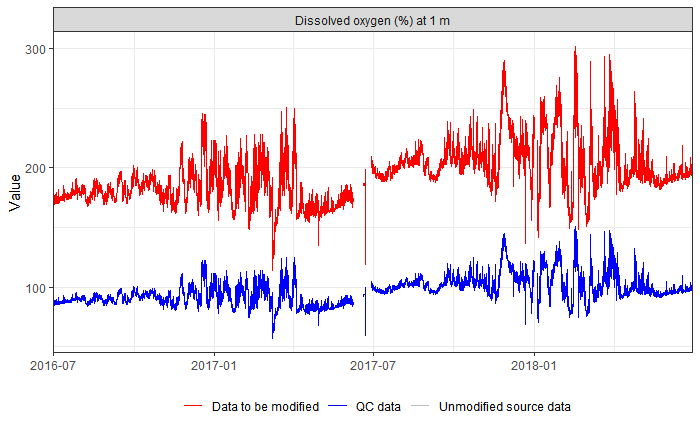

```r
2
```

**Complex example:**

calculate DO (mg/L) using ( DO (%sat) and water temperature ) using USGS method..

*Meyers, D.N. (2011) https://water.usgs.gov/admin/memo/QW/qw11.03.pdf*

eqn: DOmg = (exp(-139.34411 + ((157570.1*(1/( tmpwtr +273.15))) + (-66423080*((1/( tmpwtr +273.15))^2)) +  
(12438000000*((1/( tmpwtr +273.15))^3)) + (-862194900000*((1/( tmpwtr +273.15))^4))))) * DOsat *0.01

..where tmpwtr = water temperature and DOsat = dissolved oxygen saturation

```
[1] "Only quality controlled data are displayed for non-faceted plots"
```

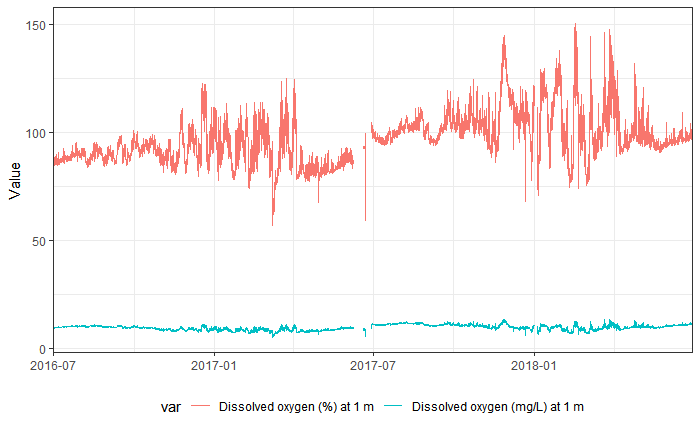

```r
rB3gg(rB3agg2,
      varNames = c('DOpsat.d00050','DOconc.d00050'),
      showPlot = T,
      srcColour = 'orange',
      qcColour = 'blue')
```

```r
# define the list of input variables required for the calculation
eqnVars = c('TmpWtr.d00050','DOpsat.d00050')
# define the function, using eqnVars[1] - tmpwtr and eqnVars[2] = DOsat
DOsat2mg <- function(eqnVars) {
  (exp(-139.34411 + ((157570.1*(1/( eqnVars[1] +273.15))) +
      (-66423080*((1/( eqnVars[1] +273.15))^2)) +
        (12438000000*((1/( eqnVars[1] +273.15))^3)) +
           (-862194900000*((1/( eqnVars[1] +273.15))^4))))) * eqnVars[2] * 0.01
}
```

```r
rB3agg2 <- FUNCrB3(rB3agg2,
                   varNames = 'DOconc.d00050',
                   eqnVars = eqnVars,
                   FUN = DOsat2mg,
                   showPlot = T)
```

```
Apply these changes?

1: Yes
2: No

Enter an item from the menu, or 0 to exit
```

```
[1] "Changes have been applied"
```

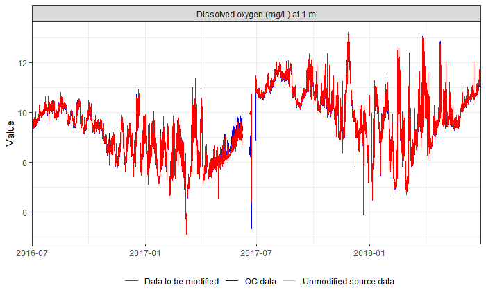

```r
1
```

## Export files as Lake Analyzer inputs

### writeLAinputs() -

write cleaned up temperature and wind data to .wtr and .wnd files for direct input to rLakeAnalyzer

?writeLAinputs

```r
writeLAinputs(rB3in = rB3agg2,
              wtrNames = 'TmpWtr',
              wndName = 'WndSpd',
              wndHeight = 1.5)
```